# Domain-general cognitive motivation: evidence from economic decision-making

JC

8/24/2021

## Summary of findings from multi-domain discounting project

### 104 YAs

```r
rm(list=ls())

# Packages
library(brms); library(bayestestR); library(correlation); library(knitr); library(kableExtra); library(RColorBrewer); library(tidyverse);
source("summarySEwithin2.R")

#Create data directories
#Cog-ED
coged.wm.path<-"~/Box/CCPLab_Aging_Studies/Multi-Domain-Discounting/Data/Online/CogED/mdd_coged_wm.csv"
coged.wm.full.path <-"~/Box/CCPLab_Aging_Studies/Multi-Domain-Discounting/Data/Online/CogED/mdd_coged_wm_full.csv"
coged.speech.path<-"~/Box/CCPLab_Aging_Studies/Multi-Domain-Discounting/Data/Online/CogED/mdd_coged_speech.csv"
#Individual Difference Questionnaires
NCS.path <- "~/Box/CCPLab_Aging_Studies/Multi-Domain-Discounting/Data/Online/Questionnaires/MDD_NCS.csv"
SSQ.path <- "~/Box/CCPLab_Aging_Studies/Multi-Domain-Discounting/Data/Online/Questionnaires/MDD_Ssq.csv"
SPSRQ.path <- "~/Box/CCPLab_Aging_Studies/Multi-Domain-Discounting/Data/Online/Questionnaires/MDD_Spsrq.csv"
BISBAS.path <- "~/Box/CCPLab_Aging_Studies/Multi-Domain-Discounting/Data/Online/Questionnaires/MDD_Bisbas.csv"
GRAPES.path <- "~/Box/CCPLab_Aging_Studies/Multi-Domain-Discounting/Data/Online/Questionnaires/MDD_Grapes.csv"
#Working Memory Capacity
LSpan.path <- "~/Box/CCPLab_Aging_Studies/Multi-Domain-Discounting/Data/Online/Listening-Span/mdd_listening-span.csv"
OSpan.path <- "~/Box/CCPLab_Aging_Studies/Multi-Domain-Discounting/Data/Online/O-Span/mdd_o-span.csv"
SymmSpan.path <- "~/Box/CCPLab_Aging_Studies/Multi-Domain-Discounting/Data/Online/Symm-Span/MDD_Symm-Span.csv"
#complete subject list
subjects.path <- "~/Box/CCPLab_Aging_Studies/Multi-Domain-Discounting/Data/Online/ID-Lists/subjects_online_MDD.csv"
#Make data frames for Cog-ED and demographics info
coged.wm<- read.csv(coged.wm.path, header = T)
coged.wm.full <- read.csv(coged.wm.full.path, header = T)
coged.speech<- read.csv(coged.speech.path, header = T)
#Make data frames for individual difference questionnaires
NCS <- read.csv(NCS.path, header = T)
SSQ <- read.csv(SSQ.path, header = T)
SPSRQ <- read.csv(SPSRQ.path, header = T)
BISBAS <- read.csv(BISBAS.path, header = T)
GRAPES <- read.csv(GRAPES.path, header = T)
#Make data frames for working memory capacity tasks
LSpan <- read.csv(LSpan.path, header = T)
OSpan <- read.csv(OSpan.path, header = T)
SymmSpan <- read.csv(SymmSpan.path, header = T)
#Make data frame for useable subject info
Subjects <- read.csv(subjects.path, header = F)
```

## Cognitive Effort Discounting

### Testing for the effects of task load, monetary reward, and domain (e.g., working memory, speech) on subjective value

```r
#Cog-ED Data
#clean data frame(s) with Cog-ED subjective value (SV) estimates and transform data so that SV estimates are equivalent across both domains (i.e., speech, WM)
##working memory
d.coged.wm <- coged.wm %>% select(subjectid,completed,fixedAmount_N2_1,fixedAmount_N2_2,fixedAmount_N2_3,fixedAmount_N3_1,fixedAmount_N3_2,
                            fixedAmount_N3_3,fixedAmount_N4_1,fixedAmount_N4_2,fixedAmount_N4_3,
                            IP12_1,IP12_2,IP12_3,IP13_1,IP13_2,IP13_3,IP14_1,IP14_2,IP14_3) %>%
  filter(completed == 1) %>%
  group_by(subjectid) %>%
  mutate(Domain = "WM",
         domainCode = 0,
         SV2_1 = ifelse(fixedAmount_N2_1 == "X", IP12_1/2, ((2-IP12_1)/2)+1),
         SV2_2 = ifelse(fixedAmount_N2_2 == "X", IP12_2/3, ((3-IP12_2)/3)+1),
         SV2_3 = ifelse(fixedAmount_N2_3 == "X", IP12_1/4, ((4-IP12_3)/4)+1),
         SV3_1 = ifelse(fixedAmount_N3_1 == "X", IP13_1/2, ((2-IP13_1)/2)+1),
         SV3_2 = ifelse(fixedAmount_N3_2 == "X", IP13_2/3, ((3-IP13_2)/3)+1),
         SV3_3 = ifelse(fixedAmount_N3_3 == "X", IP13_1/4, ((4-IP13_3)/4)+1),
         SV4_1 = ifelse(fixedAmount_N4_1 == "X", IP14_1/2, ((2-IP14_1)/2)+1),
         SV4_2 = ifelse(fixedAmount_N4_2 == "X", IP14_2/3, ((3-IP14_2)/3)+1),
         SV4_3 = ifelse(fixedAmount_N4_3 == "X", IP14_3/4, ((4-IP14_3)/4)+1),
         SV_red = (SV2_1 + SV2_2 + SV2_3)/3,
         SV_blue = (SV3_1 + SV3_2 + SV3_3)/3,
         SV_purple = (SV4_1 + SV4_2 + SV4_3)/3)

##speech comprehension
d.coged.speech <- coged.speech %>%
  select(subjectid,completed,fixedAmount_N2_1,fixedAmount_N2_2,fixedAmount_N2_3,fixedAmount_N3_1,
                            fixedAmount_N3_2,fixedAmount_N3_3,fixedAmount_N4_1,fixedAmount_N4_2,fixedAmount_N4_3,
                            IP12_1,IP12_2,IP12_3,IP13_1,IP13_2,IP13_3,IP14_1,IP14_2,IP14_3) %>%
  filter(completed == 1) %>%
  group_by(subjectid) %>%
  mutate(Domain = "Speech",
         domainCode = 1,
         SV2_1 = ifelse(fixedAmount_N2_1 == "X", IP12_1/2, ((2-IP12_1)/2)+1),
         SV2_2 = ifelse(fixedAmount_N2_2 == "X", IP12_2/3, ((3-IP12_2)/3)+1),
         SV2_3 = ifelse(fixedAmount_N2_3 == "X", IP12_1/4, ((4-IP12_3)/4)+1),
         SV3_1 = ifelse(fixedAmount_N3_1 == "X", IP13_1/2, ((2-IP13_1)/2)+1),
         SV3_2 = ifelse(fixedAmount_N3_2 == "X", IP13_2/3, ((3-IP13_2)/3)+1),
         SV3_3 = ifelse(fixedAmount_N3_3 == "X", IP13_1/4, ((4-IP13_3)/4)+1),
         SV4_1 = ifelse(fixedAmount_N4_1 == "X", IP14_1/2, ((2-IP14_1)/2)+1),
         SV4_2 = ifelse(fixedAmount_N4_2 == "X", IP14_2/3, ((3-IP14_2)/3)+1),
         SV4_3 = ifelse(fixedAmount_N4_3 == "X", IP14_3/4, ((4-IP14_3)/4)+1),
         SV_red = (SV2_1 + SV2_2 + SV2_3)/3,
         SV_blue = (SV3_1 + SV3_2 + SV3_3)/3,
         SV_purple = (SV4_1 + SV4_2 + SV4_3)/3)
#Merge WM and Speech Cog-ED data frames
coged.merged <- rbind(d.coged.wm, d.coged.speech)

#Filter out subjects who have not completed all tasks in the protocol
colnames(Subjects) <- "subjectid"
coged.merged <-inner_join(Subjects, coged.merged)

#Add dummy variables (task, domain) for multilevel models
d.coged.SV <- coged.merged %>% select(subjectid,Domain,domainCode, SV_red, SV_blue, SV_purple) %>%
  pivot_longer(names_to = "tmp", values_to = "SV", -c(subjectid,Domain,domainCode)) %>%
  separate(col = tmp, into=c(NA,"Task"), sep = "_") %>%
  mutate(taskCode = factor(Task, levels=c("red","blue","purple"), labels=c(-1,0,1)))
d.coged.SV$taskCode <- as.numeric(d.coged.SV$taskCode)
d.coged.SV$domainCode <- as.numeric(d.coged.SV$domainCode)
#Multilevel model of subjective value with task and domain as predictors
m.SV.coged <- brm(data = d.coged.SV, SV ~ taskCode*domainCode + (1 | subjectid), file = "models/m.SV.coged.rds")
summary(m.SV.coged)
```

```
##  Family: gaussian
##   Links: mu = identity; sigma = identity
## Formula: SV ~ taskCode * domainCode + (1 | subjectid)
##    Data: d.coged.SV (Number of observations: 624)
##   Draws: 4 chains, each with iter = 2000; warmup = 1000; thin = 1;
##          total post-warmup draws = 4000
##
## Group-Level Effects:
## ~subjectid (Number of levels: 104)
##               Estimate Est.Error l-95% CI u-95% CI Rhat Bulk_ESS Tail_ESS
## sd(Intercept)     0.21      0.02     0.18     0.25 1.00     1355     2075
##
## Population-Level Effects:
##                     Estimate Est.Error l-95% CI u-95% CI Rhat Bulk_ESS Tail_ESS
## Intercept               0.66      0.04     0.57     0.74 1.00     2058     2878
## taskCode               -0.09      0.02    -0.13    -0.05 1.00     3158     3281
## domainCode              0.12      0.06     0.01     0.23 1.00     2881     3217
## taskCode:domainCode    -0.10      0.03    -0.15    -0.04 1.00     2749     3219
##
## Family Specific Parameters:
##       Estimate Est.Error l-95% CI u-95% CI Rhat Bulk_ESS Tail_ESS
## sigma     0.27      0.01     0.26     0.29 1.00     4912     2913
##
## Draws were sampled using sampling(NUTS). For each parameter, Bulk_ESS
## and Tail_ESS are effective sample size measures, and Rhat is the potential
## scale reduction factor on split chains (at convergence, Rhat = 1).
```

```r
#Add in reward code (in addition to task level and domain) as predictors in model
d.coged.SV.full <- coged.merged %>% select(subjectid,Domain,domainCode, SV2_1, SV2_2, SV2_3, SV3_1, SV3_2, SV3_3, SV4_1, SV4_2, SV4_3) %>%
  pivot_longer(names_to = "tmp", values_to = "SV", -c(subjectid,Domain,domainCode)) %>%
  separate(col = tmp, into=c("Task","Reward"), sep = "_") %>%
  mutate(taskCode = factor(Task, levels=c("SV2","SV3","SV4"), labels=c(-1,0,1)),
         rewardCode = factor(Reward, levels = c(1,2,3), labels = c(-1,0,1)))
d.coged.SV.full$taskCode <- as.numeric(d.coged.SV.full$taskCode)
d.coged.SV.full$domainCode <- as.numeric(d.coged.SV.full$domainCode)
d.coged.SV.full$rewardCode <- as.numeric(d.coged.SV.full$rewardCode)

#Multilevel model of subjective value with task and domain as predictors
m.SV.coged.full <- brm(data = d.coged.SV.full, SV ~ taskCode*domainCode*rewardCode + (1 | subjectid), file = "models/m.SV.coged.full.rds")
summary(m.SV.coged.full)
```

```
##  Family: gaussian
##   Links: mu = identity; sigma = identity
## Formula: SV ~ taskCode * domainCode * rewardCode + (1 | subjectid)
##    Data: d.coged.SV.full (Number of observations: 1872)
##   Draws: 4 chains, each with iter = 2000; warmup = 1000; thin = 1;
##          total post-warmup draws = 4000
##
## Group-Level Effects:
## ~subjectid (Number of levels: 104)
##               Estimate Est.Error l-95% CI u-95% CI Rhat Bulk_ESS Tail_ESS
## sd(Intercept)     0.23      0.02     0.20     0.27 1.00      957     1451
##
## Population-Level Effects:
##                                Estimate Est.Error l-95% CI u-95% CI Rhat
## Intercept                          1.09      0.07     0.95     1.24 1.00
## taskCode                          -0.24      0.03    -0.30    -0.18 1.00
## domainCode                         0.04      0.10    -0.16     0.24 1.00
## rewardCode                        -0.22      0.03    -0.28    -0.16 1.00
## taskCode:domainCode               -0.06      0.05    -0.15     0.03 1.00
## taskCode:rewardCode                0.08      0.02     0.05     0.10 1.00
## domainCode:rewardCode              0.04      0.05    -0.05     0.13 1.00
## taskCode:domainCode:rewardCode    -0.02      0.02    -0.06     0.02 1.00
##                                Bulk_ESS Tail_ESS
## Intercept                          1087     1755
## taskCode                           1056     2231
## domainCode                          995     2088
## rewardCode                         1101     2308
## taskCode:domainCode                1074     2249
## taskCode:rewardCode                1059     2078
## domainCode:rewardCode              1013     2290
## taskCode:domainCode:rewardCode     1100     2168
##
## Family Specific Parameters:
##       Estimate Est.Error l-95% CI u-95% CI Rhat Bulk_ESS Tail_ESS
## sigma     0.30      0.00     0.29     0.31 1.00     7716     3109
##
## Draws were sampled using sampling(NUTS). For each parameter, Bulk_ESS
## and Tail_ESS are effective sample size measures, and Rhat is the potential
## scale reduction factor on split chains (at convergence, Rhat = 1).
```

### Plotting SV estimates across working memory and speech comprehension domains

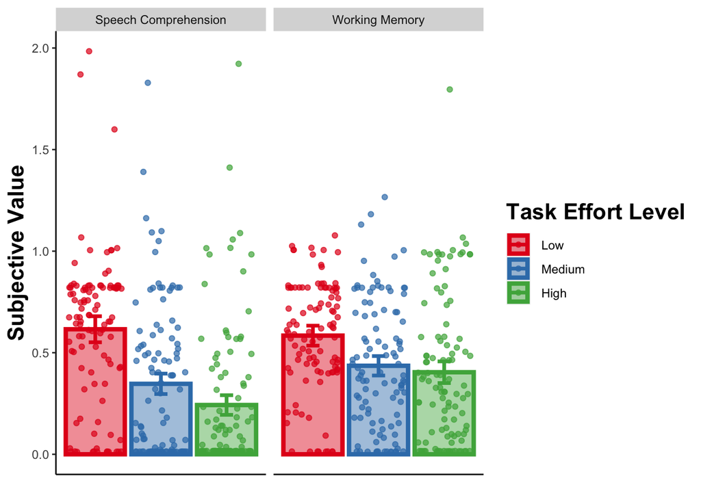

```r
#Plotting SV estimates
#Create summary stats for group plots
CogED_sum <- summarySEwithin2(d.coged.SV, measurevar = "SV", withinvars = c("Task","Domain"), idvar = "subjectid")
CogED_sum$Task <- factor(CogED_sum$Task, levels = c("red","blue","purple"), labels = c("red","blue","purple"))
CogED_sum$Domain <- factor(CogED_sum$Domain, levels = c("WM","Speech"), labels = c("WM","Speech"))

#Plotting SV across both gain and loss domains
Domain.labs <- c("Speech Comprehension", "Working Memory")
names(Domain.labs) <- c("Speech", "WM")

fig.1 <- ggplot(CogED_sum, aes(x=Task, y=SV, fill=Task, color=Task)) +
  theme(plot.title = element_text(hjust = 0.5), panel.grid.major = element_blank(), panel.grid.minor = element_blank(), panel.background = element_blank(), axis.line = element_line(colour = "black"), axis.title.y = element_text(face="bold", size=16),legend.title = element_text(face="bold", size=16)) +
  geom_bar(stat="identity", position=position_dodge(), alpha=.45, size=1.5) +
  geom_errorbar(position=position_dodge(width=0.9), aes(ymin=SV-ci, ymax=SV+ci), width=.2, size=1.25) +
  geom_point(data = d.coged.SV, aes(x=Task, y=SV, color=Task),
             stat="identity", alpha=0.7, position = "jitter") +
  scale_x_discrete(breaks=NULL) +
  xlab("") + ylab("Subjective Value") +
  facet_wrap(.~ Domain, labeller = labeller(Domain = Domain.labs))
fig.1 + scale_fill_brewer(palette = "Set1",  name="Task Effort Level", labels=c("Low","Medium","High")) + scale_color_brewer(palette = "Set1", name="Task Effort Level",labels=c("Low","Medium","High"))
```

```r
#Plotting SV estimates
#Create summary stats for group plots
CogED_Rew_sum <- summarySEwithin2(d.coged.SV.full, measurevar = "SV", withinvars = c("Task","Domain","Reward"), idvar = "subjectid")
CogED_Rew_sum$Task <- factor(CogED_Rew_sum$Task, levels = c("SV2","SV3","SV4"), labels = c("Low Effort","Medium Effort","High Effort"))
CogED_Rew_sum$Reward <- factor(CogED_Rew_sum$Reward, levels = c("1","2","3"), labels = c("Low Reward","Medium Reward","High Reward"))
CogED_Rew_sum$Domain <- factor(CogED_Rew_sum$Domain, levels = c("WM","Speech"), labels = c("WM","Speech"))

#Plotting SV across both gain and loss domains
Domain.labs <- c("Speech Comprehension", "Working Memory")
names(Domain.labs) <- c("Speech", "WM")
```

## Stage I of Analysis: Zero-order correlation between average subjective value across working memory and speech comprehension domains

```r
#Correlating Average SV (within-subj) across domains
average.SV <- coged.merged %>% select(subjectid, Domain, SV_red, SV_blue, SV_purple) %>%
  group_by(subjectid, Domain) %>%
  dplyr::summarise(SV_avg = (SV_red + SV_blue + SV_purple)/3) %>%
  pivot_wider(values_from = "SV_avg", names_from = "Domain")

#Testing for correlation between cognitive effort discounting across working memory & speech domains
CogED.cor <- cor_test(data = average.SV, x = "Speech", y = "WM", bayesian = TRUE, bayesian_prior = 0.707107)
#Summarize Bayes Factor from correlation
CogED.cor
```

```
## Parameter1 | Parameter2 |  rho |       95% CI |        pd | % in ROPE |               Prior |      BF
## -----------------------------------------------------------------------------------------------------
## Speech     |         WM | 0.29 | [0.15, 0.44] | 99.92%*** |     2.23% | Beta (1.41 +- 1.41) | 14.69**
##
## Observations: 104
```

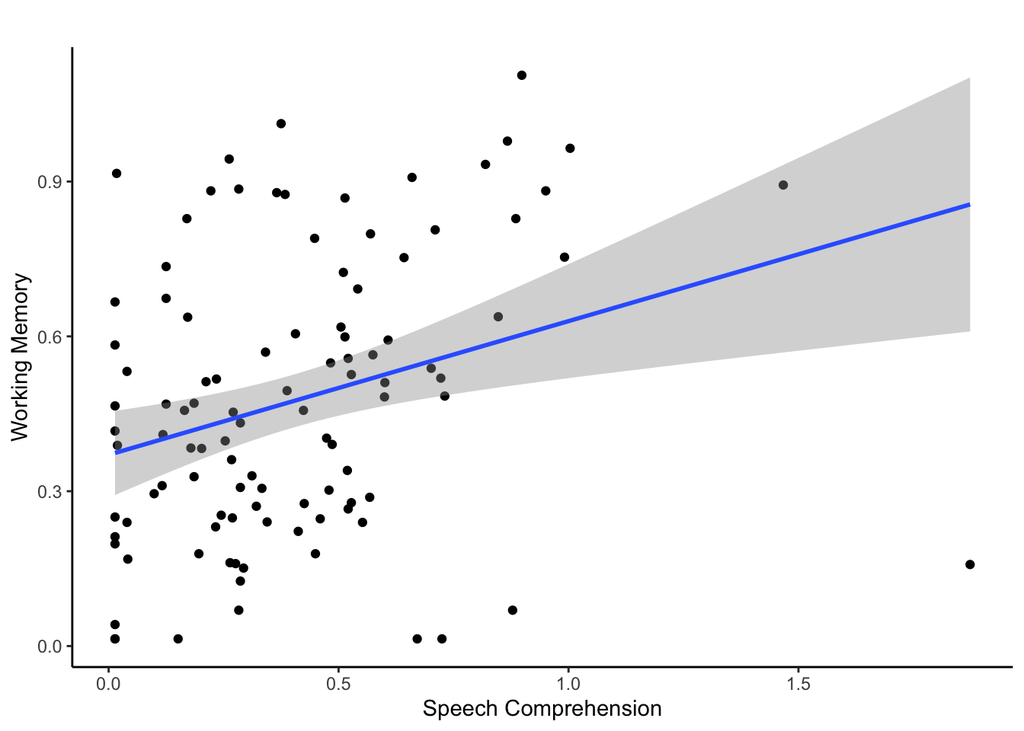

```r
#Plot of correlation between working memory & speech comprehension domains
fig.2 <- ggplot(average.SV, aes(Speech, WM)) +
   theme(plot.title = element_text(hjust = 0.5), panel.grid.major = element_blank(), panel.grid.minor = element_blank(), panel.background = element_blank(), axis.line = element_line(colour = "black")) +
  geom_point() + geom_smooth(method=lm) +ggtitle("") +
    xlab("Speech Comprehension") + ylab("Working Memory")
fig.2
```

## Stage II of Analysis: Partialing out task level and performance on subjective value estimates

### Familiarization Phase Performance

### Speech

```r
performance.speech <- coged.speech %>% select(subjectid, completed, percentCorrect_N1, percentCorrect_N2, percentCorrect_N3, percentCorrect_N4) %>%
   group_by(subjectid) %>% filter(completed == 1) %>% select(-completed) %>%
  pivot_longer(names_to = "level", values_to = "performance", -c(subjectid)) %>%
  separate(col = level, into=c(NA,"Task"), sep = "_") %>% inner_join(Subjects)
performance.speech$task <- factor(performance.speech$Task, levels = c("N1","N2","N3","N4"), labels = c("black","red","blue","purple"))

performance_sum <- summarySEwithin2(performance.speech, measurevar = "performance", withinvars = c("Task"), idvar = "subjectid")
performance_sum$Task <- factor(performance_sum$Task, levels = c("N1","N2","N3","N4"), labels = c("0 SNR","-4 SNR","-8 SNR","-12 SNR"))

performance.table <- kable(performance_sum %>% select(!contains("Normed")), caption = "Mean Accuracy of Keywords across Load Levels") %>%  kable_styling(bootstrap_options = c("striped", "hover", "condensed"))
performance.table
```

Mean Accuracy of Keywords across Load Levels

| Task | N | performance | sd | se | ci |
| --- | --- | --- | --- | --- | --- |
| 0 SNR | 104 | 80.49038 | 8.897817 | 0.8725027 | 1.730403 |
| -4 SNR | 104 | 72.63462 | 9.493588 | 0.9309229 | 1.846266 |
| -8 SNR | 104 | 45.13462 | 9.456016 | 0.9272386 | 1.838959 |
| -12 SNR | 104 | 14.04808 | 12.203593 | 1.1966607 | 2.373294 |

### Working Memory

```r
performance.wm <- coged.wm %>% select(subjectid, completed, hitrate_N1, CRrate_N1, hitrate_N2, CRrate_N2, hitrate_N3, CRrate_N3, hitrate_N4, CRrate_N4) %>%
   group_by(subjectid) %>% filter(completed == 1) %>% select(-completed) %>%
  pivot_longer(names_to = "level", values_to = "performance", -c(subjectid)) %>%
  separate(col = level, into=c("Metric","Task"), sep = "_") %>%
  pivot_wider(names_from = Metric, values_from = performance)  %>% inner_join(Subjects)
performance.wm$task <- factor(performance.wm$Task, levels = c("N1","N2","N3","N4"), labels = c("black","red","blue","purple"))

performance.sum.wm <- summarySEwithin2(performance.wm, measurevar = "hitrate", withinvars = c("Task"), idvar = "subjectid")
performance.sum.wm$Task <- factor(performance.sum.wm$Task, levels = c("N1","N2","N3","N4"), labels = c("1-back","2-back","3-back","4-back"))

performance.wm.RT <- coged.wm.full %>% select(subject, blockcode, phase, response, latency) %>% filter(phase == 1) %>%
  rename(task = "blockcode", subjectid = "subject") %>% filter(task != "ratingSummary") %>% filter(response != 0)
performance.wm.RT$task <- factor(performance.wm.RT$task, levels = c("1back","2back","3back","4back"), labels = c("black","red","blue","purple"))

performance.wm.RT.sum <-inner_join(performance.wm.RT, Subjects) %>% group_by(subjectid, task) %>% summarise(meanRT = mean(latency))

performance.table.wm <- kable(performance.sum.wm %>% select(!contains("Normed")), caption = "Hit rate across Load Levels") %>%  kable_styling(bootstrap_options = c("striped", "hover", "condensed"))
performance.table.wm
```

Hit rate across Load Levels

| Task | N | hitrate | sd | se | ci |
| --- | --- | --- | --- | --- | --- |
| 1-back | 104 | 0.7653846 | 0.2332989 | 0.0228768 | 0.0453708 |
| 2-back | 104 | 0.8153846 | 0.1862452 | 0.0182628 | 0.0362200 |
| 3-back | 104 | 0.6692308 | 0.2330961 | 0.0228569 | 0.0453314 |
| 4-back | 104 | 0.6326923 | 0.2442206 | 0.0239478 | 0.0474948 |

### Correlation between averaged residuals from models controlling for the effects of task level & performance

```r
#Working Memory Cog-ED
#Summarize average performance on N-Back
d.coged.wm.clean <- d.coged.wm %>% select(subjectid, SV_red, SV_blue, SV_purple) %>%
  pivot_longer(names_to = "tmp", values_to = "SV", -subjectid) %>%
   separate(col = tmp, into=c(NA,"task"), sep = "_")

d.coged.wm.partial <- d.coged.wm.clean %>% group_by(subjectid,task) %>% summarise(meanSV = mean(SV)) %>%
  inner_join(performance.wm, by = c("subjectid","task")) %>% inner_join(performance.wm.RT.sum) %>%
  mutate(taskCode = factor(task, levels =c( "black","red","blue","purple"), labels = c(-2,-1,0,1)),
         FArate = 1-CRrate,
         HR_z = scale(hitrate),
         FAR_z = scale(FArate),
         dPrime = HR_z - FAR_z)

d.coged.wm.partial$taskCode <- as.numeric(d.coged.wm.partial$taskCode)

m.SV.wm.partial <- brm(data = d.coged.wm.partial, meanSV ~ taskCode + hitrate + CRrate + meanRT + (1 | subjectid), file = "models/m.SV.wm.partial.rds")
summary(m.SV.wm.partial)
```

```
##  Family: gaussian
##   Links: mu = identity; sigma = identity
## Formula: meanSV ~ taskCode + hitrate + CRrate + meanRT + (1 | subjectid)
##    Data: d.coged.wm.partial (Number of observations: 312)
##   Draws: 4 chains, each with iter = 2000; warmup = 1000; thin = 1;
##          total post-warmup draws = 4000
##
## Group-Level Effects:
## ~subjectid (Number of levels: 104)
##               Estimate Est.Error l-95% CI u-95% CI Rhat Bulk_ESS Tail_ESS
## sd(Intercept)     0.25      0.02     0.21     0.29 1.00      991     1852
##
## Population-Level Effects:
##           Estimate Est.Error l-95% CI u-95% CI Rhat Bulk_ESS Tail_ESS
## Intercept     0.78      0.13     0.52     1.04 1.00     1976     2728
## taskCode     -0.07      0.01    -0.10    -0.05 1.00     4993     2867
## hitrate       0.20      0.06     0.09     0.31 1.00     3297     2900
## CRrate       -0.06      0.09    -0.23     0.12 1.00     2185     2751
## meanRT       -0.00      0.00    -0.00    -0.00 1.00     2959     3260
##
## Family Specific Parameters:
##       Estimate Est.Error l-95% CI u-95% CI Rhat Bulk_ESS Tail_ESS
## sigma     0.19      0.01     0.17     0.21 1.00     2404     2753
##
## Draws were sampled using sampling(NUTS). For each parameter, Bulk_ESS
## and Tail_ESS are effective sample size measures, and Rhat is the potential
## scale reduction factor on split chains (at convergence, Rhat = 1).
```

```r
subj.resid.wm <- m.SV.wm.partial[["data"]][["subjectid"]] %>% as_tibble()
colnames(subj.resid.wm) <- "subjectid"
res.WM <- residuals(m.SV.wm.partial) %>% as_tibble() %>% select(Estimate)
colnames(res.WM) <- "resid.wm"
res.subj.WM <- cbind(subj.resid.wm, res.WM)

#Speech Cog-ED
d.coged.speech.clean <- d.coged.speech %>% select(subjectid, SV_red, SV_blue, SV_purple) %>%
  pivot_longer(names_to = "tmp", values_to = "SV", -subjectid) %>%
   separate(col = tmp, into=c(NA,"task"), sep = "_")

d.coged.speech.partial <- d.coged.speech.clean %>% group_by(subjectid,task) %>% summarise(meanSV = mean(SV)) %>%
  inner_join(performance.speech, by = c("subjectid","task")) %>%
  mutate(taskCode = factor(task, levels =c("red","blue","purple"), labels = c(-1,0,1)))
d.coged.speech.partial$taskCode <- as.numeric(d.coged.speech.partial$taskCode)

m.SV.speech.partial <- brm(data = d.coged.speech.partial, meanSV ~ taskCode + performance + (1 | subjectid), file = "models/m.SV.speech.partial.rds")
summary(m.SV.speech.partial)
```

```
##  Family: gaussian
##   Links: mu = identity; sigma = identity
## Formula: meanSV ~ taskCode + performance + (1 | subjectid)
##    Data: d.coged.speech.partial (Number of observations: 312)
##   Draws: 4 chains, each with iter = 2000; warmup = 1000; thin = 1;
##          total post-warmup draws = 4000
##
## Group-Level Effects:
## ~subjectid (Number of levels: 104)
##               Estimate Est.Error l-95% CI u-95% CI Rhat Bulk_ESS Tail_ESS
## sd(Intercept)     0.29      0.03     0.24     0.34 1.00     1451     2338
##
## Population-Level Effects:
##             Estimate Est.Error l-95% CI u-95% CI Rhat Bulk_ESS Tail_ESS
## Intercept       0.54      0.13     0.29     0.79 1.00     2410     2903
## taskCode       -0.12      0.04    -0.19    -0.05 1.00     2572     2874
## performance     0.00      0.00    -0.00     0.00 1.00     2401     3014
##
## Family Specific Parameters:
##       Estimate Est.Error l-95% CI u-95% CI Rhat Bulk_ESS Tail_ESS
## sigma     0.23      0.01     0.21     0.26 1.00     3117     3266
##
## Draws were sampled using sampling(NUTS). For each parameter, Bulk_ESS
## and Tail_ESS are effective sample size measures, and Rhat is the potential
## scale reduction factor on split chains (at convergence, Rhat = 1).
```

```r
subj.resid.speech <- m.SV.speech.partial[["data"]][["subjectid"]] %>% as_tibble()
colnames(subj.resid.speech) <- "subjectid"
res.speech <-residuals(m.SV.speech.partial) %>% as_tibble() %>% select(Estimate)
colnames(res.speech) <- "resid.speech"
res.subj.Speech <- cbind(subj.resid.speech, res.speech)

SV.resids <- cbind(res.subj.WM, res.speech) %>% group_by(subjectid) %>% summarise(mean.resid.wm = mean(resid.wm), mean.resid.speech = mean(resid.speech))
#Testing for correlation between cognitive effort discounting across working memory & speech domains (controlling for task performance)
CogED.cor.partial <- cor_test(data = SV.resids, x = "mean.resid.wm", y = "mean.resid.speech", bayesian = TRUE, bayesian_prior = 0.707107)
#Summarize Bayes Factor from correlation controlling for task performance
CogED.cor.partial
```

```
## Parameter1    |        Parameter2 |  rho |       95% CI |        pd | % in ROPE |               Prior |      BF
## ---------------------------------------------------------------------------------------------------------------
## mean.resid.wm | mean.resid.speech | 0.31 | [0.17, 0.45] | 99.95%*** |     1.30% | Beta (1.41 +- 1.41) | 26.72**
##
## Observations: 104
```

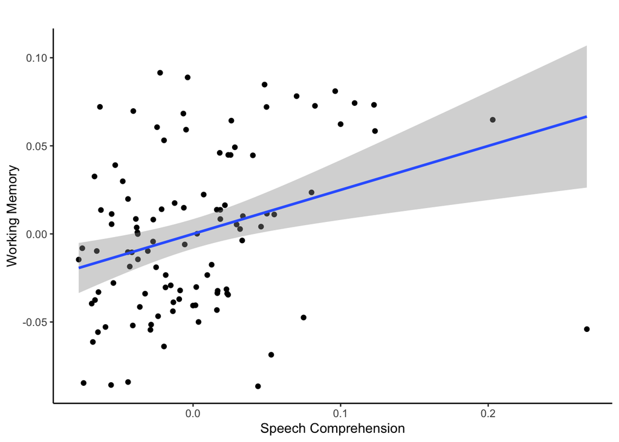

```r
#Plot of correlation between working memory & speech comprehension domains controlling for task level & performance
fig.resid <- ggplot(SV.resids, aes(mean.resid.speech, mean.resid.wm)) +
   theme(plot.title = element_text(hjust = 0.5), panel.grid.major = element_blank(), panel.grid.minor = element_blank(), panel.background = element_blank(), axis.line = element_line(colour = "black")) +
  geom_point() + geom_smooth(method=lm) +ggtitle("") +
    xlab("Speech Comprehension") + ylab("Working Memory")
fig.resid
```

## Stage III of Analysis: Partial Correlation

### Reward Motivation (BIS/BAS, SPSRQ, GRAPES)

```r
#BIS/BAS
#Importing and cleaning BIS/BAS
BISBAS.clean <- BISBAS %>% select(c(subjectid,completed, BAS_Drive, BAS_Fun, BAS_Reward, BIS)) %>% distinct(subjectid, .keep_all=T) %>% mutate(BAS_total = BAS_Drive + BAS_Fun + BAS_Reward)
BISBAS.SV <- inner_join(average.SV, BISBAS.clean)

#SPSRQ
#Importing and cleaning SPSRQ
SPSRQ.clean <- SPSRQ %>% select(c(subjectid, completed, SensitivityToReward, SensitivityToPunishment)) %>% distinct(subjectid, .keep_all=T)
SPSRQ.SV <- inner_join(average.SV, SPSRQ.clean)

#GRAPES
GRAPES.clean <- GRAPES %>% select(c(subject, ends_with("response"))) %>% distinct(subject, .keep_all=T) %>%
  mutate(GRAPES.rew = q1_response + q4_response + q6_response + q7_response + q9_response + q10_response + q15_response +
         q16_response + q16_response + q19_response + q20_response + q21_response + q25_response + q26_response + q27_response,
         GRAPES.pun = q2_response + q3_response + q5_response + q8_response + q11_response + q12_response + q13_response +
         q14_response + q18_response + q22_response + q23_response + q24_response + q28_response + q29_response + q30_response) %>%
  rename(subjectid = "subject")
GRAPES.SV <- inner_join(average.SV, GRAPES.clean)
```

### Working Memory Capacity (Listing Span, Operation Span, Symmetry Span)

```r
#Importing and cleaning WMC measures
#Listening Span
LSpan.clean <- LSpan %>% select(c(subjectid, completed, ListeningSpanScore)) %>% distinct(subjectid, .keep_all=T)
LSpan.SV <- inner_join(average.SV, LSpan.clean)

#Operation Span
OSpan.clean <- OSpan %>% select(c(subjectid, completed, ospan)) %>% distinct(subjectid, .keep_all=T)
OSpan.SV <- inner_join(average.SV, OSpan.clean)

#Symmetry Span
SymSpan.clean <- SymmSpan %>% select(c(subjectid, completed, sspan)) %>% distinct(subjectid, .keep_all=T)
SymSpan.SV <- inner_join(average.SV, SymSpan.clean)
```

### Partial correlation controlling for WMC and reward sensitivity (from residualized SV estimates)

```r
#Create data frame with WMC measures, get z-scores, and create a composite measure
LSpan.comp <- LSpan.SV %>% select(-c(Speech, WM))
LSpan.comp$LSpan.z <- scale(LSpan.comp$ListeningSpanScore)
OSpan.comp <- OSpan.SV %>% select(-c(Speech, WM))
OSpan.comp$OSpan.z <- scale(OSpan.comp$ospan)
SymSpan.comp <- SymSpan.SV %>% select(-c(Speech, WM))
SymSpan.comp$SSpan.z <- scale(SymSpan.comp$sspan)

WMC <- inner_join(LSpan.comp, OSpan.comp, by = "subjectid") %>% inner_join(SymSpan.comp, by = "subjectid") %>%
  filter(completed.x == 1) %>% filter(completed.y == 1) %>% filter(completed == 1) %>%
  select(-c("completed.x","completed.y","completed")) %>%
  mutate(WMC.composite = (LSpan.z + OSpan.z + SSpan.z)) %>%
  select(subjectid, WMC.composite)

#Create data frame with reward sensitivity measures, get z-scores, and create a composite measure
BISBAS.comp <- BISBAS.SV %>% select(-c(Speech, WM, BAS_Drive, BAS_Fun, BAS_Reward, BIS))
BISBAS.comp$BAS.z <- scale(BISBAS.comp$BAS_total)
SPSRQ.comp <- SPSRQ.SV %>% select(-c(Speech, WM, SensitivityToPunishment))
SPSRQ.comp$SPSRQ.rew.z <- scale(SPSRQ.comp$SensitivityToReward)
GRAPES.comp <- GRAPES.SV %>% select(c(subjectid, GRAPES.rew))
GRAPES.comp$GRAPES.rew.z <- scale(GRAPES.comp$GRAPES.rew)

Reward.composite <- inner_join(BISBAS.comp, SPSRQ.comp, by = "subjectid") %>% inner_join(GRAPES.comp, by = "subjectid") %>%
  filter(completed.x == 1) %>% filter(completed.y == 1) %>%
  select(-c("completed.x","completed.y")) %>%
  mutate(Rew.composite = (BAS.z + SPSRQ.rew.z + GRAPES.rew.z)) %>%
  select(subjectid, Rew.composite)

#Testing for partial correlation between residuals (from stage two) controlling for WMC and reward sensitivity
SV.composite.resid <- inner_join(WMC, Reward.composite, by = "subjectid") %>% inner_join(SV.resids, by = "subjectid")
SV.composite.resid.clean <- cbind(SV.composite.resid$WMC.composite, SV.composite.resid$Rew.composite, SV.composite.resid$mean.resid.speech, SV.composite.resid$mean.resid.wm) %>% as_tibble()
colnames(SV.composite.resid.clean) <- c("WMC", "Reward", "Speech", "WM")

WMC.resid.cor <- cor_test(data = SV.composite.resid.clean, x = "WM", y = "Speech", bayesian = TRUE, partial_bayesian = TRUE, bayesian_prior  = 0.707107)
#Summarize Bayes Factor from correlation
WMC.resid.cor
```

```
## Parameter1 | Parameter2 |  rho |       95% CI |        pd | % in ROPE |               Prior |       BF
## ------------------------------------------------------------------------------------------------------
## WM         |     Speech | 0.33 | [0.19, 0.47] | 99.98%*** |     0.57% | Beta (1.41 +- 1.41) | 76.16***
##
## Observations: 104
```

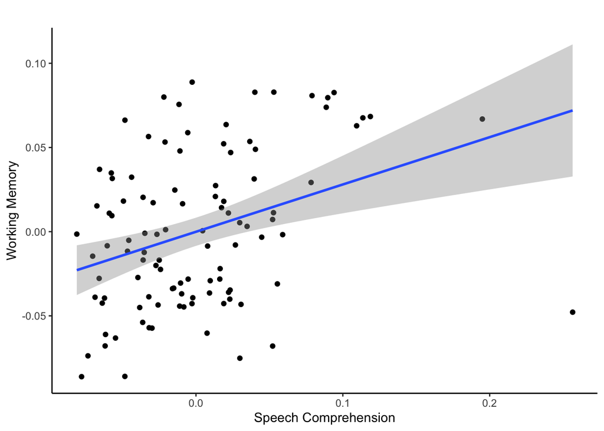

```r
#WM Cog-ED
d.coged.wm.partial.test <- inner_join(d.coged.wm.partial, WMC, by = "subjectid") %>% inner_join(Reward.composite, by = "subjectid")
m.SV.wm.partial.test <- brm(data = d.coged.wm.partial.test, meanSV ~ taskCode + hitrate + CRrate + meanRT + WMC.composite + Rew.composite + (1 | subjectid), file = "models/m.SV.wm.partial.test.rds")

subj.resid.wm.test <- m.SV.wm.partial.test[["data"]][["subjectid"]] %>% as_tibble()
colnames(subj.resid.wm.test) <- "subjectid"
res.WM.test <- resid(m.SV.wm.partial.test) %>% as_tibble() %>% select(Estimate)
colnames(res.WM.test) <- "resid.wm"
res.subj.WM.test <- cbind(subj.resid.wm.test, res.WM.test)

#Speech Cog-ED
d.coged.speech.partial.test <- inner_join(d.coged.speech.partial, WMC, by = "subjectid") %>% inner_join(Reward.composite, by = "subjectid")
m.SV.speech.partial.test <- brm(data = d.coged.speech.partial.test, meanSV ~ taskCode + performance + WMC.composite + Rew.composite + (1 | subjectid), file = "models/m.SV.speech.partial.test.rds")

subj.resid.speech.test <- m.SV.speech.partial.test[["data"]][["subjectid"]] %>% as_tibble()
colnames(subj.resid.speech.test) <- "subjectid"
res.speech.test <-residuals(m.SV.speech.partial.test) %>% as_tibble() %>% select(Estimate)
colnames(res.speech.test) <- "resid.speech"
res.subj.Speech.test <- cbind(subj.resid.speech.test, res.speech.test)

SV.resids.test <- cbind(res.subj.WM.test, res.speech.test) %>% group_by(subjectid) %>% summarise(mean.resid.wm = mean(resid.wm), mean.resid.speech = mean(resid.speech))
#Testing for correlation between cognitive effort discounting across working memory & speech domains (controlling for task performance)
CogED.cor.partial.test <- cor_test(data = SV.resids.test, x = "mean.resid.wm", y = "mean.resid.speech", bayesian = TRUE, bayesian_prior = 0.707107)

#Plot of correlation between working memory & speech comprehension domains controlling for task level, performance, WMC, and reward sensitivity
fig.resid.2 <- ggplot(SV.resids.test, aes(mean.resid.speech, mean.resid.wm)) +
   theme(plot.title = element_text(hjust = 0.5), panel.grid.major = element_blank(), panel.grid.minor = element_blank(), panel.background = element_blank(), axis.line = element_line(colour = "black")) +
  geom_point() + geom_smooth(method=lm) +ggtitle("") +
    xlab("Speech Comprehension") + ylab("Working Memory")
fig.resid.2
```

# Supplemental Information & Analyses

## Removing Participants who have an average SV >1

### Zero-order correlation between working memory and speech subjective value estimates

#### 99 YAs

```r
#Correlating Average SV (within-subj) across domains
average.SV.outliers <- coged.merged %>% select(subjectid, Domain, SV_red, SV_blue, SV_purple) %>%
  group_by(subjectid, Domain) %>%
  dplyr::summarise(SV_avg = (SV_red + SV_blue + SV_purple)/3) %>%
  pivot_wider(values_from = "SV_avg", names_from = "Domain") %>%
  filter(Speech < 1) %>% filter(WM < 1)

#Testing for correlation between cognitive effort discounting across working memory & speech domains
CogED.cor.adj <- cor_test(data = average.SV.outliers, x = "Speech", y = "WM", bayesian = TRUE, bayesian_prior = 0.707107)
#Summarize Bayes Factor from correlation
CogED.cor.adj
```

```
## Parameter1 | Parameter2 |  rho |       95% CI |        pd | % in ROPE |               Prior |      BF
## -----------------------------------------------------------------------------------------------------
## Speech     |         WM | 0.31 | [0.17, 0.45] | 99.92%*** |     1.35% | Beta (1.41 +- 1.41) | 21.91**
##
## Observations: 99
```

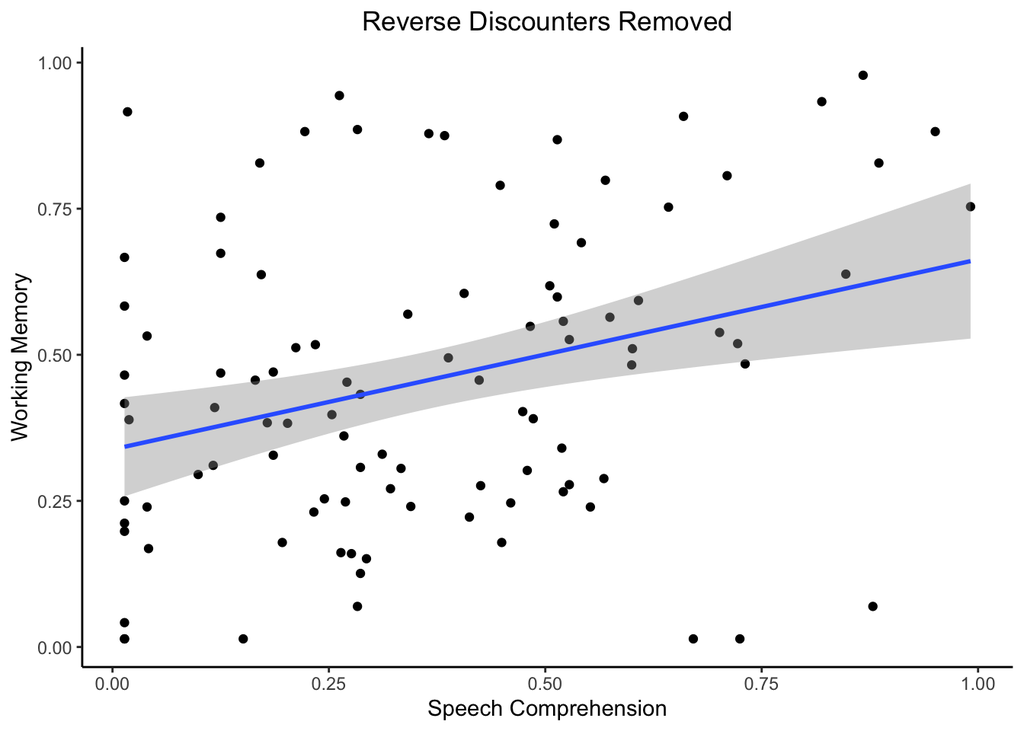

```r
#Plot of correlation between working memory & speech comprehension domains (Figure 2)
fig.outlier.rm <- ggplot(average.SV.outliers, aes(Speech, WM)) +
   theme(plot.title = element_text(hjust = 0.5), panel.grid.major = element_blank(), panel.grid.minor = element_blank(), panel.background = element_blank(), axis.line = element_line(colour = "black")) +
  geom_point() + geom_smooth(method=lm) +ggtitle("Reverse Discounters Removed") +
    xlab("Speech Comprehension") + ylab("Working Memory")
fig.outlier.rm
```

### Correlation between averaged residuals from models controlling for the effects of task level & performance

```r
#Working Memory Cog-ED
#Summarize average performance on N-Back
outlier.subjs <- average.SV.outliers$subjectid %>% as_tibble()
colnames(outlier.subjs) <- "subjectid"

d.coged.wm.partial.outlier <- inner_join(d.coged.wm.partial, outlier.subjs)

m.SV.wm.partial.outlier <- brm(data = d.coged.wm.partial.outlier, meanSV ~ taskCode + hitrate + CRrate + meanRT + (1 | subjectid), file = "models/m.SV.wm.partial.outlier.rds")
summary(m.SV.wm.partial.outlier)
```

```
##  Family: gaussian
##   Links: mu = identity; sigma = identity
## Formula: meanSV ~ taskCode + hitrate + CRrate + meanRT + (1 | subjectid)
##    Data: d.coged.wm.partial.outlier (Number of observations: 297)
##   Draws: 4 chains, each with iter = 2000; warmup = 1000; thin = 1;
##          total post-warmup draws = 4000
##
## Group-Level Effects:
## ~subjectid (Number of levels: 99)
##               Estimate Est.Error l-95% CI u-95% CI Rhat Bulk_ESS Tail_ESS
## sd(Intercept)     0.24      0.02     0.20     0.28 1.00     1200     2355
##
## Population-Level Effects:
##           Estimate Est.Error l-95% CI u-95% CI Rhat Bulk_ESS Tail_ESS
## Intercept     0.64      0.13     0.38     0.90 1.00     1776     2809
## taskCode     -0.08      0.01    -0.11    -0.05 1.00     4562     2960
## hitrate       0.19      0.05     0.09     0.30 1.00     2887     3272
## CRrate        0.05      0.09    -0.12     0.25 1.00     2038     2429
## meanRT       -0.00      0.00    -0.00     0.00 1.00     2337     2871
##
## Family Specific Parameters:
##       Estimate Est.Error l-95% CI u-95% CI Rhat Bulk_ESS Tail_ESS
## sigma     0.18      0.01     0.16     0.20 1.00     2532     3086
##
## Draws were sampled using sampling(NUTS). For each parameter, Bulk_ESS
## and Tail_ESS are effective sample size measures, and Rhat is the potential
## scale reduction factor on split chains (at convergence, Rhat = 1).
```

```r
subj.resid.wm.outlier <- m.SV.wm.partial.outlier[["data"]][["subjectid"]] %>% as_tibble()
colnames(subj.resid.wm.outlier) <- "subjectid"
res.WM.outlier <- resid(m.SV.wm.partial.outlier) %>% as_tibble() %>% select(Estimate)
colnames(res.WM.outlier) <- "resid.wm"
res.subj.WM.outlier <- cbind(subj.resid.wm.outlier, res.WM.outlier)

#Speech Cog-ED
d.coged.speech.partial.outlier <- inner_join(d.coged.speech.partial, outlier.subjs)

m.SV.speech.partial.outlier <- brm(data = d.coged.speech.partial.outlier, meanSV ~ taskCode + performance + (1 | subjectid), file = "models/m.SV.speech.partial.outlier.rds")
summary(m.SV.speech.partial.outlier)
```

```
##  Family: gaussian
##   Links: mu = identity; sigma = identity
## Formula: meanSV ~ taskCode + performance + (1 | subjectid)
##    Data: d.coged.speech.partial.outlier (Number of observations: 297)
##   Draws: 4 chains, each with iter = 2000; warmup = 1000; thin = 1;
##          total post-warmup draws = 4000
##
## Group-Level Effects:
## ~subjectid (Number of levels: 99)
##               Estimate Est.Error l-95% CI u-95% CI Rhat Bulk_ESS Tail_ESS
## sd(Intercept)     0.20      0.02     0.16     0.25 1.00     1348     2167
##
## Population-Level Effects:
##             Estimate Est.Error l-95% CI u-95% CI Rhat Bulk_ESS Tail_ESS
## Intercept       0.35      0.13     0.10     0.60 1.00     2614     2931
## taskCode       -0.08      0.04    -0.15    -0.00 1.00     2998     2948
## performance     0.00      0.00     0.00     0.01 1.00     2727     3119
##
## Family Specific Parameters:
##       Estimate Est.Error l-95% CI u-95% CI Rhat Bulk_ESS Tail_ESS
## sigma     0.24      0.01     0.21     0.26 1.00     2491     2983
##
## Draws were sampled using sampling(NUTS). For each parameter, Bulk_ESS
## and Tail_ESS are effective sample size measures, and Rhat is the potential
## scale reduction factor on split chains (at convergence, Rhat = 1).
```

```r
subj.resid.speech.outlier <- m.SV.speech.partial.outlier[["data"]][["subjectid"]] %>% as_tibble()
colnames(subj.resid.speech.outlier) <- "subjectid"
res.speech.outlier <-residuals(m.SV.speech.partial.outlier) %>% as_tibble() %>% select(Estimate)
colnames(res.speech.outlier) <- "resid.speech"
res.subj.Speech.outlier <- cbind(subj.resid.speech.outlier, res.speech.outlier)

SV.resids.outlier <- cbind(res.subj.WM.outlier, res.speech.outlier) %>% group_by(subjectid) %>% summarise(mean.resid.wm = mean(resid.wm), mean.resid.speech = mean(resid.speech))
#Testing for correlation between cognitive effort discounting across working memory & speech domains (controlling for task performance)
CogED.cor.partial.outlier <- cor_test(data = SV.resids.outlier, x = "mean.resid.wm", y = "mean.resid.speech", bayesian = TRUE, bayesian_prior = 0.707107)
#Summarize Bayes Factor from correlation controlling for task performance
CogED.cor.partial.outlier
```

```
## Parameter1    |        Parameter2 |  rho |       95% CI |        pd | % in ROPE |               Prior |        BF
## -----------------------------------------------------------------------------------------------------------------
## mean.resid.wm | mean.resid.speech | 0.36 | [0.23, 0.51] | 99.95%*** |     0.60% | Beta (1.41 +- 1.41) | 196.66***
##
## Observations: 99
```

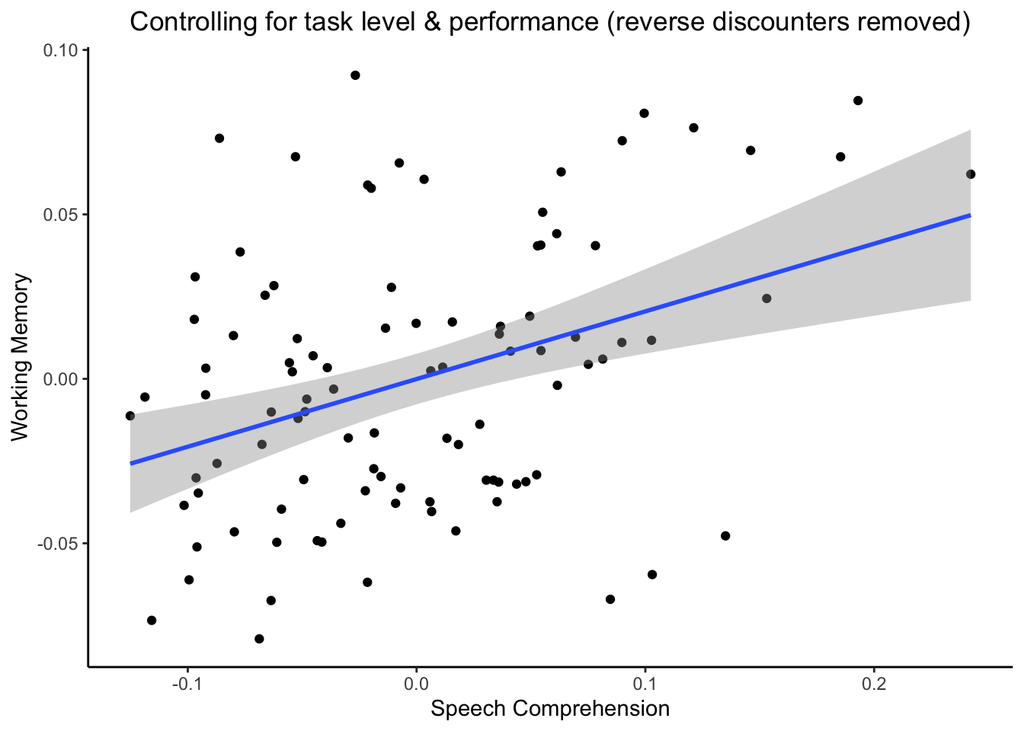

```r
#Plot of correlation between working memory & speech comprehension domains controlling for task level & performance
fig.resid.outlier <- ggplot(SV.resids.outlier, aes(mean.resid.speech, mean.resid.wm)) +
   theme(plot.title = element_text(hjust = 0.5), panel.grid.major = element_blank(), panel.grid.minor = element_blank(), panel.background = element_blank(), axis.line = element_line(colour = "black")) +
  geom_point() + geom_smooth(method=lm) +ggtitle("Controlling for task level & performance (reverse discounters removed)") +
    xlab("Speech Comprehension") + ylab("Working Memory")
fig.resid.outlier
```

### Partial correlation controlling for WMC and reward sensitivity (from residualized SV estimates)

```r
#Create data frame with WMC measures, get z-scores, and create a composite measure
WMC.outlier <- inner_join(WMC, outlier.subjs, by = "subjectid")

#Create data frame with reward sensitivity measures, get z-scores, and create a composite measure
Reward.composite.outlier <- inner_join(Reward.composite, outlier.subjs, by = "subjectid")

#Testing for partial correlation between residuals (from stage two) controlling for WMC and reward sensitivity
SV.composite.resid.outlier <- inner_join(WMC.outlier, Reward.composite.outlier, by = "subjectid") %>% inner_join(SV.resids.outlier, by = "subjectid")
SV.composite.resid.outlier.clean <- cbind(SV.composite.resid.outlier$WMC.composite, SV.composite.resid.outlier$Rew.composite, SV.composite.resid.outlier$mean.resid.speech, SV.composite.resid.outlier$mean.resid.wm) %>% as_tibble()
colnames(SV.composite.resid.outlier.clean) <- c("WMC", "Reward", "Speech", "WM")

WMC.resid.cor.outlier <- cor_test(data = SV.composite.resid.outlier.clean, x = "WM", y = "Speech", bayesian = TRUE, partial_bayesian = TRUE, bayesian_prior  = 0.707107)
#Summarize Bayes Factor from correlation
WMC.resid.cor.outlier
```

```
## Parameter1 | Parameter2 |  rho |       95% CI |      pd | % in ROPE |               Prior |        BF
## -----------------------------------------------------------------------------------------------------
## WM         |     Speech | 0.38 | [0.25, 0.51] | 100%*** |     0.10% | Beta (1.41 +- 1.41) | 447.66***
##
## Observations: 99
```

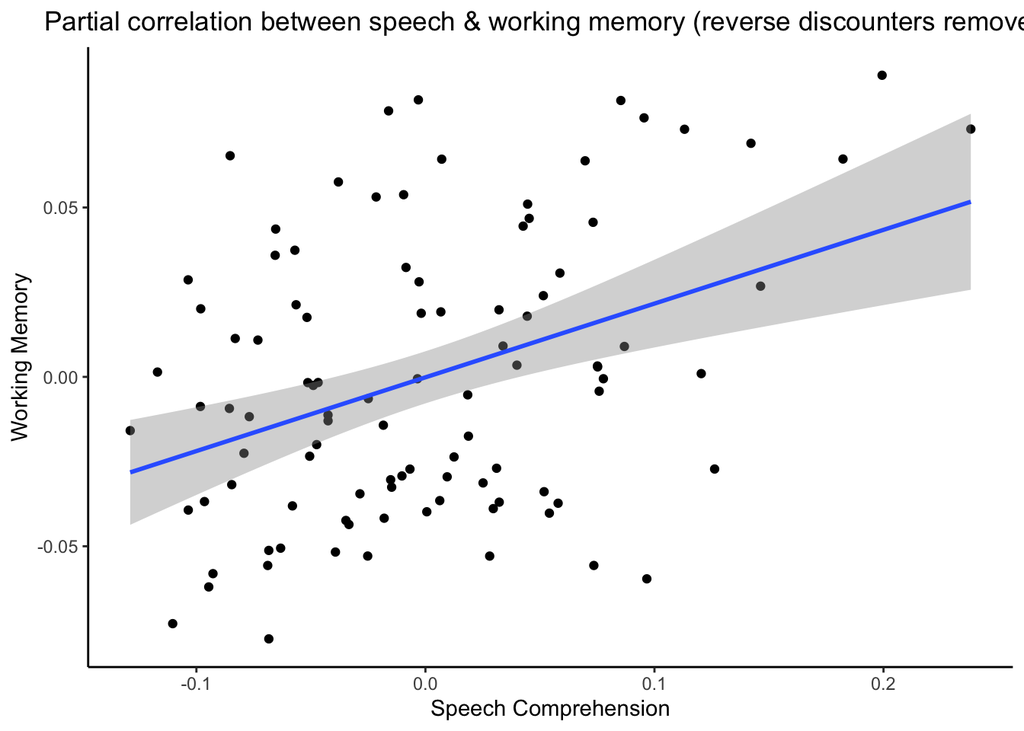

```r
#WM Cog-ED
d.coged.wm.partial.outlier.plot <- inner_join(d.coged.wm.partial.outlier, WMC.outlier, by = "subjectid") %>% inner_join(Reward.composite.outlier, by = "subjectid")
m.SV.wm.partial.outlier.plot <- brm(data = d.coged.wm.partial.outlier.plot, meanSV ~ taskCode + hitrate + CRrate + meanRT + WMC.composite + Rew.composite + (1 | subjectid), file = "models/m.SV.wm.partial.outlier.plot.rds")

subj.resid.wm.outlier.plot <- m.SV.wm.partial.outlier.plot[["data"]][["subjectid"]] %>% as_tibble()
colnames(subj.resid.wm.outlier.plot) <- "subjectid"
res.WM.outlier.plot <- residuals(m.SV.wm.partial.outlier.plot) %>% as_tibble() %>% select(Estimate)
colnames(res.WM.outlier.plot) <- "resid.wm"
res.subj.WM.outlier.plot <- cbind(subj.resid.wm.outlier.plot, res.WM.outlier.plot)

#Speech Cog-ED
d.coged.speech.partial.outlier.plot <- inner_join(d.coged.speech.partial.outlier, WMC.outlier, by = "subjectid") %>% inner_join(Reward.composite.outlier, by = "subjectid")
m.SV.speech.partial.outlier.plot <- brm(data = d.coged.speech.partial.outlier.plot, meanSV ~ taskCode + performance + WMC.composite + Rew.composite + (1 | subjectid), file = "models/m.SV.speech.partial.outlier.plot.rds")

subj.resid.speech.outlier.plot <- m.SV.speech.partial.outlier.plot[["data"]][["subjectid"]] %>% as_tibble()
colnames(subj.resid.speech.outlier.plot) <- "subjectid"
res.speech.outlier.plot <-residuals(m.SV.speech.partial.outlier.plot) %>% as_tibble() %>% select(Estimate)
colnames(res.speech.outlier.plot) <- "resid.speech"
res.subj.Speech.outlier.plot <- cbind(subj.resid.speech.outlier.plot, res.speech.outlier.plot)

SV.resids.outlier.plot <- cbind(res.subj.WM.outlier.plot, res.speech.outlier.plot) %>% group_by(subjectid) %>% summarise(mean.resid.wm = mean(resid.wm), mean.resid.speech = mean(resid.speech))
#Testing for correlation between cognitive effort discounting across working memory & speech domains (controlling for task performance)
CogED.cor.partial.outlier.plot <- cor_test(data = SV.resids.outlier.plot, x = "mean.resid.wm", y = "mean.resid.speech", bayesian = TRUE, bayesian_prior = 0.707107)

#Plot of correlation between working memory & speech comprehension domains controlling for task level, performance, WMC, and reward sensitivity
fig.resid.outlier.plot <- ggplot(SV.resids.outlier.plot, aes(mean.resid.speech, mean.resid.wm)) +
   theme(plot.title = element_text(hjust = 0.5), panel.grid.major = element_blank(), panel.grid.minor = element_blank(), panel.background = element_blank(), axis.line = element_line(colour = "black")) +
  geom_point() + geom_smooth(method=lm) +ggtitle("Partial correlation between speech & working memory (reverse discounters removed)") +
    xlab("Speech Comprehension") + ylab("Working Memory")
fig.resid.outlier.plot
```

## Additional analysis: Partial correlation controlling for WMC and reward sensitivity using average SV estimates (not residuals)

```r
#Testing for correlation between WMC Composite and N-Back Familiarization Phase Performance
SV.composite <- inner_join(WMC, Reward.composite, by = "subjectid") %>% inner_join(average.SV, by = "subjectid")

SV.composite.clean <- cbind(SV.composite$WMC.composite, SV.composite$Rew.composite, SV.composite$Speech, SV.composite$WM) %>% as_tibble()

colnames(SV.composite.clean) <- c("WMC", "Reward", "Speech", "WM")

WMC.cor <- cor_test(data = SV.composite.clean, x = "WM", y = "Speech", bayesian = TRUE, partial_bayesian = TRUE, bayesian_prior  = 0.707107)
#Summarize Bayes Factor from correlation
WMC.cor
```

```
## Parameter1 | Parameter2 |  rho |       95% CI |       pd | % in ROPE |               Prior |       BF
## -----------------------------------------------------------------------------------------------------
## WM         |     Speech | 0.32 | [0.17, 0.45] | 99.88%** |     1.03% | Beta (1.41 +- 1.41) | 38.82***
##
## Observations: 104
```

## Additional analysis: Breaking down discounting by monetary reward level (e.g., low-$2, medium-$3, high-$4)

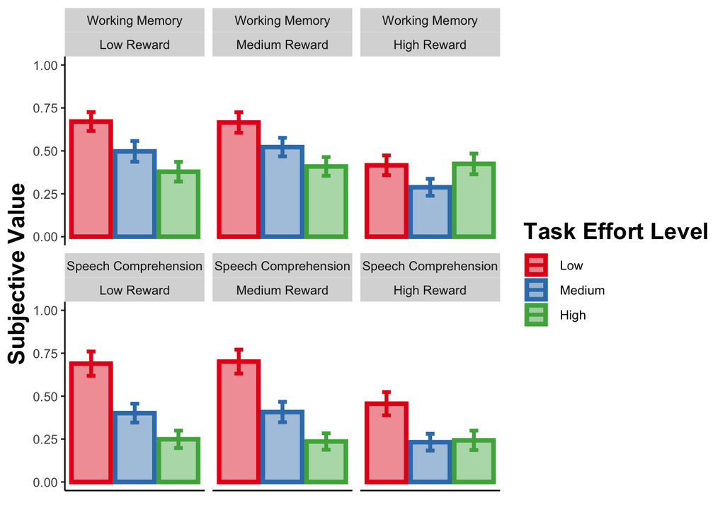

```r
fig.rew <- ggplot(CogED_Rew_sum, aes(x=Task, y=SV, fill=Task, color=Task)) +
  theme(plot.title = element_text(hjust = 0.5), panel.grid.major = element_blank(), panel.grid.minor = element_blank(), panel.background = element_blank(), axis.line = element_line(colour = "black"), axis.title.y = element_text(face="bold", size=16),legend.title = element_text(face="bold", size=16)) +
  geom_bar(stat="identity", position=position_dodge(), alpha=.45, size=1.5) +
  geom_errorbar(position=position_dodge(width=0.9), aes(ymin=SV-ci, ymax=SV+ci), width=.2, size=1.25) +
  scale_x_discrete(breaks=NULL) +
  coord_cartesian(ylim = c(0,1)) +
  xlab("") + ylab("Subjective Value") +
  facet_wrap(.~ Domain + Reward, labeller = labeller(Domain = Domain.labs))
fig.rew + scale_fill_brewer(palette = "Set1",  name="Task Effort Level", labels=c("Low","Medium","High")) + scale_color_brewer(palette = "Set1", name="Task Effort Level",labels=c("Low","Medium","High"))
```

## NASA TLX

#### Participants completed NASA ratings after each load level during the familiarization phase (likert scale: 1-21; higher values indicate greater endorsement)

```r
#Mental Demand Ratings
NASA.m.demand.wm <- coged.wm %>% select(subjectid, completed, mentaldemand_1, mentaldemand_2, mentaldemand_3, mentaldemand_4) %>%
  group_by(subjectid) %>%
  filter(completed == 1) %>%
  mutate(Domain = "WM")

NASA.m.demand.speech <- coged.speech %>% select(subjectid, completed, mentaldemand_1, mentaldemand_2, mentaldemand_3, mentaldemand_4) %>%
  group_by(subjectid) %>%
  filter(completed == 1) %>%
  mutate(Domain = "Speech")

NASA.m.demand <- rbind(NASA.m.demand.wm,NASA.m.demand.speech) %>% select(-completed) %>%
  pivot_longer(names_to = "mental_demand", values_to = "rating", -c(subjectid,Domain)) %>%
  separate(col = mental_demand, into=c(NA,"Task"), sep = "_") %>%
  mutate(taskCode = factor(Task, levels=c(1,2,3,4), labels=c(0,1,2,3)),
          domainCode = factor(Domain, levels = c("WM","Speech"), labels = c(0,1)))

NASA.m.demand$taskCode <- as.numeric(NASA.m.demand$taskCode)
NASA.m.demand$domainCode <- as.numeric(NASA.m.demand$domainCode)
NASA_mdemand_sum <- summarySEwithin2(NASA.m.demand, measurevar = "rating", withinvars = c("Task","Domain"), idvar = "subjectid")
NASA_mdemand_sum$Task <- factor(NASA_mdemand_sum$Task, levels = c(1,2,3,4), labels = c("black","red","blue","purple"))

m.mentalDemand <- brm(data = NASA.m.demand, rating ~ taskCode*domainCode + (1 | subjectid), file = "models/m.mentalDemand.rds")
summary(m.mentalDemand)
```

```
##  Family: gaussian
##   Links: mu = identity; sigma = identity
## Formula: rating ~ taskCode * domainCode + (1 | subjectid)
##    Data: NASA.m.demand (Number of observations: 872)
##   Draws: 4 chains, each with iter = 2000; warmup = 1000; thin = 1;
##          total post-warmup draws = 4000
##
## Group-Level Effects:
## ~subjectid (Number of levels: 109)
##               Estimate Est.Error l-95% CI u-95% CI Rhat Bulk_ESS Tail_ESS
## sd(Intercept)     2.63      0.22     2.23     3.11 1.00     1089     1620
##
## Population-Level Effects:
##                     Estimate Est.Error l-95% CI u-95% CI Rhat Bulk_ESS Tail_ESS
## Intercept               3.56      0.99     1.66     5.50 1.00     2289     2033
## taskCode                3.64      0.35     2.94     4.31 1.00     2300     2498
## domainCode              3.10      0.61     1.88     4.30 1.00     2421     1991
## taskCode:domainCode    -0.57      0.22    -0.99    -0.13 1.00     2328     2396
##
## Family Specific Parameters:
##       Estimate Est.Error l-95% CI u-95% CI Rhat Bulk_ESS Tail_ESS
## sigma     3.65      0.09     3.47     3.84 1.00     4542     3255
##
## Draws were sampled using sampling(NUTS). For each parameter, Bulk_ESS
## and Tail_ESS are effective sample size measures, and Rhat is the potential
## scale reduction factor on split chains (at convergence, Rhat = 1).
```

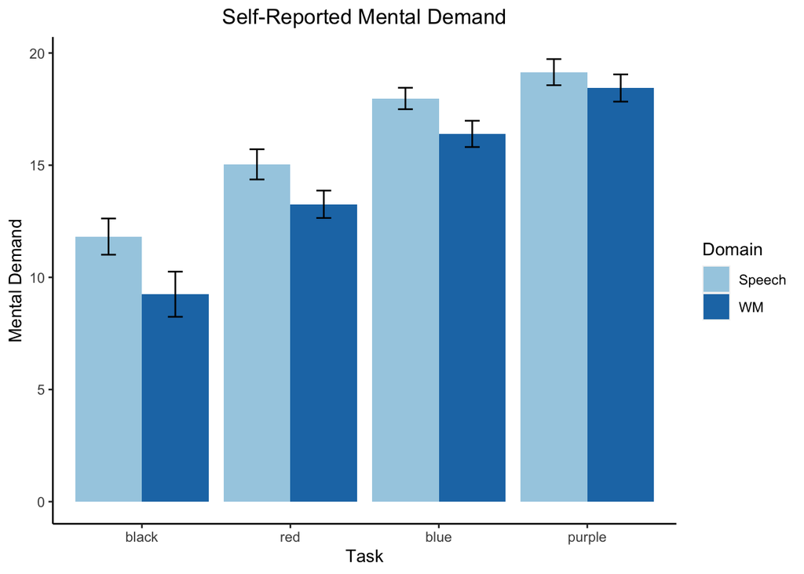

```r
p.m.demand <- ggplot(NASA_mdemand_sum, aes(x=Task, y=rating, fill=Domain)) +
  theme(plot.title = element_text(hjust = 0.5), panel.grid.major = element_blank(), panel.grid.minor = element_blank(), panel.background = element_blank(), axis.line = element_line(colour = "black")) +
  geom_bar(stat="identity", position=position_dodge()) +
  geom_errorbar(position=position_dodge(width=0.9), aes(ymin=rating-ci, ymax=rating+ci), width=.2) +
  xlab("Task") + ylab("Mental Demand") + ggtitle("Self-Reported Mental Demand")
p.m.demand + labs(fill = "Domain") + scale_fill_brewer(palette = "Paired")
```

```r
#Frustration Ratings
NASA.frust.wm <- coged.wm %>% select(subjectid, completed, frustration_1, frustration_2, frustration_3, frustration_4) %>%
  group_by(subjectid) %>%
  filter(completed == 1) %>%
  mutate(Domain = "WM")

NASA.frust.speech <- coged.speech %>% select(subjectid, completed, frustration_1, frustration_2, frustration_3, frustration_4) %>%
  group_by(subjectid) %>%
  filter(completed == 1) %>%
  mutate(Domain = "Speech")

NASA.frust <- rbind(NASA.frust.wm,NASA.frust.speech) %>% select(-completed) %>%
  pivot_longer(names_to = "frustration", values_to = "rating", -c(subjectid, Domain)) %>%
  separate(col = frustration, into=c(NA,"Task"), sep = "_") %>%
  mutate(taskCode = factor(Task, levels=c(1,2,3,4), labels=c(0,1,2,3)),
          domainCode = factor(Domain, levels = c("WM","Speech"), labels = c(0,1)))
NASA.frust$taskCode <- as.numeric(NASA.frust$taskCode)
NASA.frust$domainCode <- as.numeric(NASA.frust$domainCode)

m.Frustration <- brm(data = NASA.frust, rating ~ taskCode*domainCode + (1 | subjectid), file = "models/m.Frustration.rds")
summary(m.Frustration)
```

```
##  Family: gaussian
##   Links: mu = identity; sigma = identity
## Formula: rating ~ taskCode * domainCode + (1 | subjectid)
##    Data: NASA.frust (Number of observations: 872)
##   Draws: 4 chains, each with iter = 2000; warmup = 1000; thin = 1;
##          total post-warmup draws = 4000
##
## Group-Level Effects:
## ~subjectid (Number of levels: 109)
##               Estimate Est.Error l-95% CI u-95% CI Rhat Bulk_ESS Tail_ESS
## sd(Intercept)     3.96      0.30     3.41     4.59 1.00      867     1616
##
## Population-Level Effects:
##                     Estimate Est.Error l-95% CI u-95% CI Rhat Bulk_ESS Tail_ESS
## Intercept               6.94      1.15     4.68     9.24 1.00     1667     1759
## taskCode                0.98      0.39     0.20     1.73 1.00     2103     1837
## domainCode              0.35      0.68    -0.95     1.67 1.00     2144     2044
## taskCode:domainCode     0.72      0.25     0.24     1.20 1.00     2017     1680
##
## Family Specific Parameters:
##       Estimate Est.Error l-95% CI u-95% CI Rhat Bulk_ESS Tail_ESS
## sigma     4.10      0.11     3.90     4.31 1.00     3492     2811
##
## Draws were sampled using sampling(NUTS). For each parameter, Bulk_ESS
## and Tail_ESS are effective sample size measures, and Rhat is the potential
## scale reduction factor on split chains (at convergence, Rhat = 1).
```

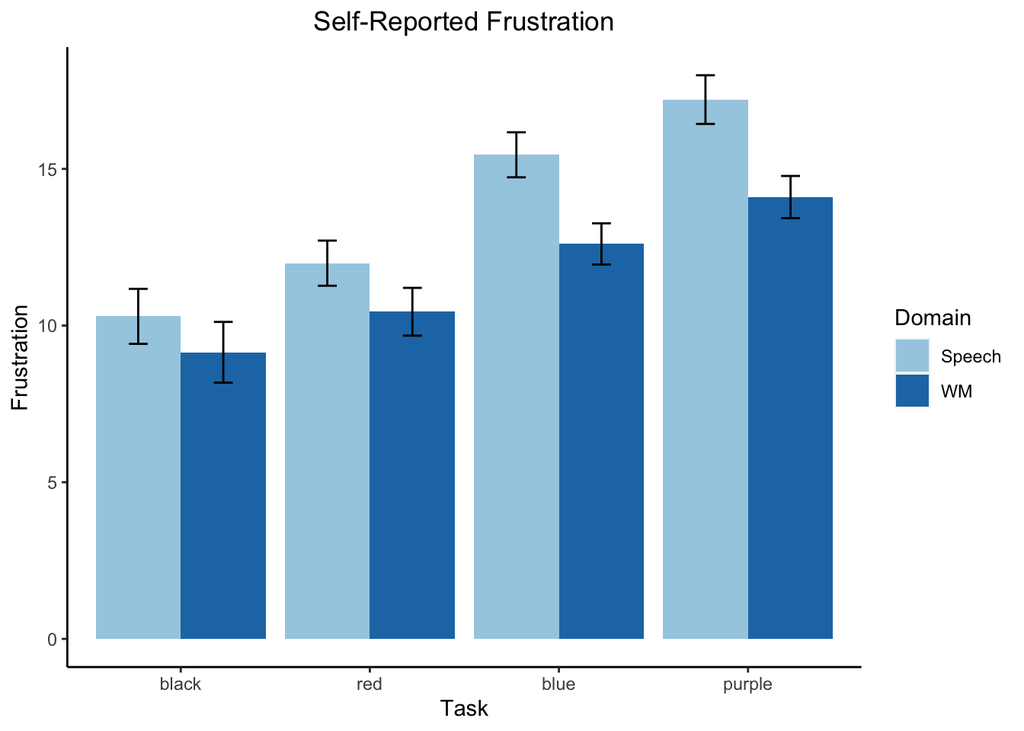

```r
NASA_frust_sum <- summarySEwithin2(NASA.frust, measurevar = "rating", withinvars = c("Task","Domain"), idvar = "subjectid")
NASA_frust_sum$Task <- factor(NASA_frust_sum$Task, levels = c(1,2,3,4), labels = c("black","red","blue","purple"))

p.frust <- ggplot(NASA_frust_sum, aes(x=Task, y=rating, fill=Domain)) +
  theme(plot.title = element_text(hjust = 0.5), panel.grid.major = element_blank(), panel.grid.minor = element_blank(), panel.background = element_blank(), axis.line = element_line(colour = "black")) +
  geom_bar(stat="identity", position=position_dodge()) +
  geom_errorbar(position=position_dodge(width=0.9), aes(ymin=rating-ci, ymax=rating+ci), width=.2) +
  xlab("Task") + ylab("Frustration") + ggtitle("Self-Reported Frustration")
p.frust +  labs(fill = "Domain") + scale_fill_brewer(palette = "Paired")
```

```r
#Effort Ratings
NASA.effort.wm <- coged.wm %>% select(subjectid, completed, effort_1, effort_2, effort_3, effort_4) %>%
  group_by(subjectid) %>%
  filter(completed == 1) %>%
  mutate(Domain = "WM")

NASA.effort.speech <- coged.speech %>% select(subjectid, completed, effort_1, effort_2, effort_3, effort_4) %>%
  group_by(subjectid) %>%
  filter(completed == 1) %>%
  mutate(Domain = "Speech")

NASA.effort <- rbind(NASA.effort.wm,NASA.effort.speech) %>% select(-completed) %>%
  pivot_longer(names_to = "effort", values_to = "rating", -c(subjectid,Domain)) %>%
  separate(col = effort, into=c(NA,"Task"), sep = "_") %>%
    mutate(taskCode = factor(Task, levels=c(1,2,3,4), labels=c(0,1,2,3)),
          domainCode = factor(Domain, levels = c("WM","Speech"), labels = c(0,1)))
NASA.effort$taskCode <- as.numeric(NASA.effort$taskCode)
NASA.effort$domainCode <- as.numeric(NASA.effort$domainCode)

m.Effort <- brm(data = NASA.effort, rating ~ taskCode*domainCode + (1 | subjectid), file = "models/m.Effort.rds")
summary(m.Effort)
```

```
##  Family: gaussian
##   Links: mu = identity; sigma = identity
## Formula: rating ~ taskCode * domainCode + (1 | subjectid)
##    Data: NASA.effort (Number of observations: 872)
##   Draws: 4 chains, each with iter = 2000; warmup = 1000; thin = 1;
##          total post-warmup draws = 4000
##
## Group-Level Effects:
## ~subjectid (Number of levels: 109)
##               Estimate Est.Error l-95% CI u-95% CI Rhat Bulk_ESS Tail_ESS
## sd(Intercept)     2.76      0.23     2.35     3.24 1.01      910     1715
##
## Population-Level Effects:
##                     Estimate Est.Error l-95% CI u-95% CI Rhat Bulk_ESS Tail_ESS
## Intercept               6.28      0.90     4.53     7.99 1.00     1507     1605
## taskCode                2.52      0.31     1.93     3.14 1.00     1628     2028
## domainCode              2.65      0.54     1.62     3.73 1.00     1777     2247
## taskCode:domainCode    -0.34      0.20    -0.74     0.04 1.00     1630     2101
##
## Family Specific Parameters:
##       Estimate Est.Error l-95% CI u-95% CI Rhat Bulk_ESS Tail_ESS
## sigma     3.33      0.09     3.16     3.49 1.00     4038     3166
##
## Draws were sampled using sampling(NUTS). For each parameter, Bulk_ESS
## and Tail_ESS are effective sample size measures, and Rhat is the potential
## scale reduction factor on split chains (at convergence, Rhat = 1).
```

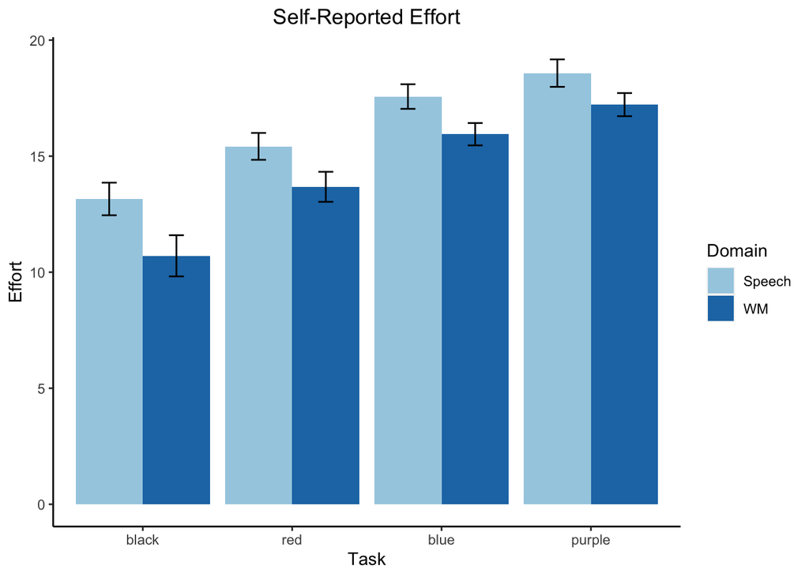

```r
NASA_effort_sum <- summarySEwithin2(NASA.effort, measurevar = "rating", withinvars = c("Task","Domain"), idvar = "subjectid")
NASA_effort_sum$Task <- factor(NASA_effort_sum$Task, levels = c(1,2,3,4), labels = c("black","red","blue","purple"))

p.effort <- ggplot(NASA_effort_sum, aes(x=Task, y=rating, fill=Domain)) +
  theme(plot.title = element_text(hjust = 0.5), panel.grid.major = element_blank(), panel.grid.minor = element_blank(), panel.background = element_blank(), axis.line = element_line(colour = "black")) +
  geom_bar(stat="identity", position=position_dodge()) +
  geom_errorbar(position=position_dodge(width=0.9), aes(ymin=rating-ci, ymax=rating+ci), width=.2) +
  xlab("Task") + ylab("Effort") + ggtitle("Self-Reported Effort")
p.effort + labs(fill = "Domain") + scale_fill_brewer(palette = "Paired")
```

## Individual Difference Questionnaires

### Relationship between average subjective value estimates and NCS scores

```r
#Importing and cleaning NCS
NCS.clean <- NCS %>% select(c(subjectid, completed, totalscore)) %>%
              distinct(subjectid, .keep_all=T)

NCS.SV <- inner_join(average.SV, NCS.clean)

#Testing for the correlation between NCS and SV estimates from both WM and Speech comprehension domains
NCS.wm.cor <- cor_test(data = NCS.SV, x = "WM", y = "totalscore", bayesian = TRUE, bayesian_prior = 0.707107)
NCS.wm.cor
```

```
## Parameter1 | Parameter2 |       rho |        95% CI |     pd | % in ROPE |               Prior |    BF
## ------------------------------------------------------------------------------------------------------
## WM         | totalscore | -2.81e-03 | [-0.15, 0.15] | 50.90% |    69.65% | Beta (1.41 +- 1.41) | 0.150
##
## Observations: 104
```

```r
NCS.speech.cor <- cor_test(data = NCS.SV, x = "Speech", y = "totalscore", bayesian = TRUE, bayesian_prior = 0.707107)
NCS.speech.cor
```

```
## Parameter1 | Parameter2 |  rho |        95% CI |     pd | % in ROPE |               Prior |    BF
## -------------------------------------------------------------------------------------------------
## Speech     | totalscore | 0.13 | [-0.02, 0.29] | 90.48% |    37.52% | Beta (1.41 +- 1.41) | 0.364
##
## Observations: 104
```

### Relationship between average speech subjective value estimate and SSQ scores (note: SSQ not available for all participants)

```r
#Importing and cleaning SSQ
SSQ.clean <- SSQ %>% select(c(subject, ends_with("response"))) %>% distinct(subject, .keep_all=T) %>%
  mutate(SSQ.total = rowSums(.[2:16]),
         SSQ.speech = rowSums(.[2:6]),
         SSQ.spatial = rowSums(.[7:11]),
         SSQ.quality = rowSums(.[12:16])) %>%
  rename(subjectid = "subject") %>%
  select(subjectid, SSQ.total, SSQ.speech, SSQ.spatial, SSQ.quality)

#Testing the correlation between SSQ total (and sub-scales) and SV estimates from both WM and Speech comprehension domains
SSQ.SV <- inner_join(average.SV, SSQ.clean)
SSQtotal.speech.cor <- cor_test(data = SSQ.SV, x = "Speech", y = "SSQ.total", bayesian = TRUE, bayesian_prior = 0.707107)
SSQtotal.speech.cor
```

```
## Parameter1 | Parameter2 |  rho |        95% CI |     pd | % in ROPE |               Prior |    BF
## -------------------------------------------------------------------------------------------------
## Speech     |  SSQ.total | 0.16 | [-0.03, 0.34] | 90.28% |    29.12% | Beta (1.41 +- 1.41) | 0.440
##
## Observations: 67
```

```r
SSQspeech.speech.cor <- cor_test(data = SSQ.SV, x = "Speech", y = "SSQ.speech", bayesian = TRUE, bayesian_prior = 0.707107)
SSQspeech.speech.cor
```

```
## Parameter1 | Parameter2 |  rho |        95% CI |     pd | % in ROPE |               Prior |    BF
## -------------------------------------------------------------------------------------------------
## Speech     | SSQ.speech | 0.15 | [-0.03, 0.34] | 88.83% |    31.57% | Beta (1.41 +- 1.41) | 0.411
##
## Observations: 67
```

```r
SSQqual.speech.cor <- cor_test(data = SSQ.SV, x = "Speech", y = "SSQ.quality", bayesian = TRUE, bayesian_prior = 0.707107)
SSQqual.speech.cor
```

```
## Parameter1 |  Parameter2 |  rho |        95% CI |     pd | % in ROPE |               Prior |    BF
## --------------------------------------------------------------------------------------------------
## Speech     | SSQ.quality | 0.02 | [-0.17, 0.22] | 55.43% |    57.30% | Beta (1.41 +- 1.41) | 0.190
##
## Observations: 67
```